# Classification Trees

A Tree is a predictive model that involves stratifying or segmenting the predictor space into a number of simple regions. Predictions are based on a summary statistic of the outcome in a given region. It is called a Decision Tree because the set of splitting rules used to segment the predictor space can be summarized in a tree.

Based on the nature of the outcome variable, trees can be categorized as  
a. Regression Trees: Outcome is continuous (e.g., price in $)  
b. Classification Trees: Outcome is categorical (e.g., whether a product is purchased or not)

Classification trees partition the data into smaller groups that contain a greater proportion of one of the categories of a categorical outcome. There are many approaches to constructing classification trees. One of the oldest and most widely used is the Classification and Regression Tree (CART) methodology.

# Load Data

For this exercise, We will derive our data from the dataset, Credit which accompanies the `ISLR2` library. The dataset contains information on credit cards and demographics for a set of 400 customers. The goal is to predict whether a person maintains a large credit balance (‘high’) or a small credit card balance (‘low’). We will create the outcome variable by doing a median split of Balance into two levels, ‘low’ and ‘high’.

```r
library(ISLR2)
data(Credit)
library(dplyr)
Credit2 =
  Credit %>%
  mutate(Balance_hilo = as.integer(Balance > median(Balance,na.rm = T)))%>%
  mutate(Balance_hilo = factor(Balance_hilo, labels = c('low','high'),ordered = T))%>%
  select(-Balance)
```

# Split Data

Conduct a 75:25 stratified split of the data on the outcome variable, Balance_hilo.

```r
library(caret)
set.seed(1031)
split = createDataPartition(y = Credit2$Balance_hilo, p = 0.75, list = F)
train = Credit2[split,]
test = Credit2[-split,]
```

# Explore

Summary of the data is displayed below. Here are a few highlights and their relevance to classification trees.  
1. Outcome variable, Balance_hilo is categorical with levels, “low” and “high” indicating level of credit balance. Since the outcome variable is categorical, we will use a Classification Tree.  
2. Predictors include categorical and continuous variables: Trees can handle both categorical and continuous predictors Categorical variables can be handled automatically, without dummy coding.  
3. Distribution of at least a few continuous variables appear to be skewed. Trees can effectively handle many type of predictors including those with skewed distributions. Predictors do not need to be transformed to make their distribution symmetric nor do they need to be standardized. Similarly, there is no need to create interaction terms to explore joint effect of two or more predictors.  
4. There are no missing values. While there are no missing values here, it is worth noting that Trees can effectively handle missing data by constructing surrogate splits.

```r
library(skimr)
skim(Credit2)
```

Data summary

| Name | Credit2 |
| --- | --- |
| Number of rows | 400 |
| Number of columns | 11 |
| _______________________ |  |
| Column type frequency: |  |
| factor | 5 |
| numeric | 6 |
| ________________________ |  |
| Group variables | None |

**Variable type: factor**

| skim_variable | n_missing | complete_rate | ordered | n_unique | top_counts |
| --- | --- | --- | --- | --- | --- |
| Own | 0 | 1 | FALSE | 2 | Yes: 207, No: 193 |
| Student | 0 | 1 | FALSE | 2 | No: 360, Yes: 40 |
| Married | 0 | 1 | FALSE | 2 | Yes: 245, No: 155 |
| Region | 0 | 1 | FALSE | 3 | Sou: 199, Wes: 102, Eas: 99 |
| Balance_hilo | 0 | 1 | TRUE | 2 | low: 200, hig: 200 |

**Variable type: numeric**

| skim_variable | n_missing | complete_rate | mean | sd | p0 | p25 | p50 | p75 | p100 | hist |
| --- | --- | --- | --- | --- | --- | --- | --- | --- | --- | --- |
| Income | 0 | 1 | 45.22 | 35.24 | 10.35 | 21.01 | 33.12 | 57.47 | 186.63 | ▇▂▁▁▁ |
| Limit | 0 | 1 | 4735.60 | 2308.20 | 855.00 | 3088.00 | 4622.50 | 5872.75 | 13913.00 | ▆▇▃▁▁ |
| Rating | 0 | 1 | 354.94 | 154.72 | 93.00 | 247.25 | 344.00 | 437.25 | 982.00 | ▆▇▃▁▁ |
| Cards | 0 | 1 | 2.96 | 1.37 | 1.00 | 2.00 | 3.00 | 4.00 | 9.00 | ▇▇▂▁▁ |
| Age | 0 | 1 | 55.67 | 17.25 | 23.00 | 41.75 | 56.00 | 70.00 | 98.00 | ▆▇▇▇▁ |
| Education | 0 | 1 | 13.45 | 3.13 | 5.00 | 11.00 | 14.00 | 16.00 | 20.00 | ▂▅▇▇▂ |

Examine distribution of numeric predictors

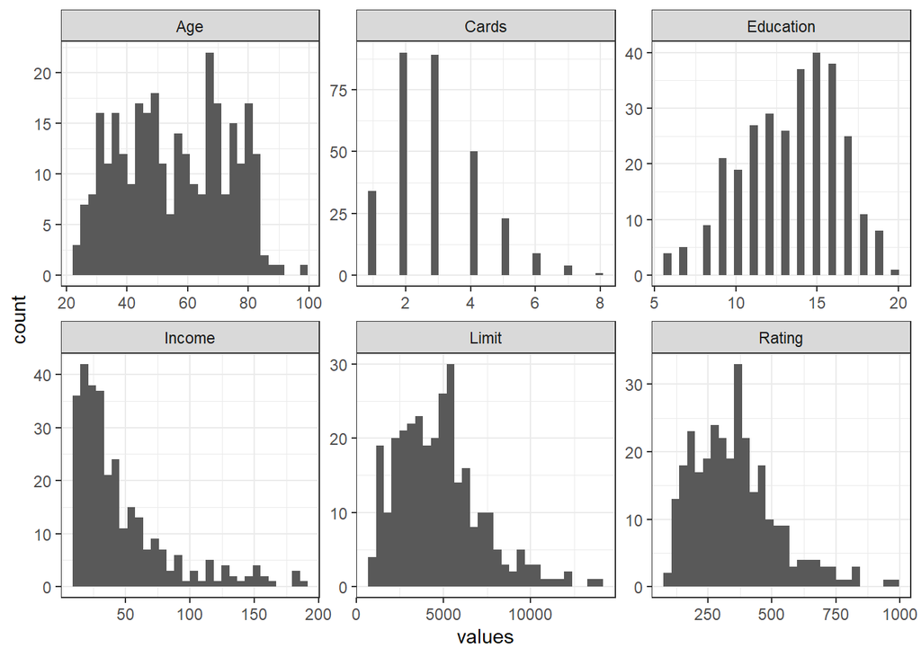

```r
library(dplyr); library(tidyr)
train %>%
  select_if(is.numeric)%>%
  pivot_longer(cols = 1:6,names_to = 'numeric_predictor', values_to = 'values')%>%
  ggplot(aes(x = values))+
  geom_histogram()+
  facet_wrap(numeric_predictor~., scales = 'free')+
  theme_bw()
```

Examine frequency distribution for categorical predictors

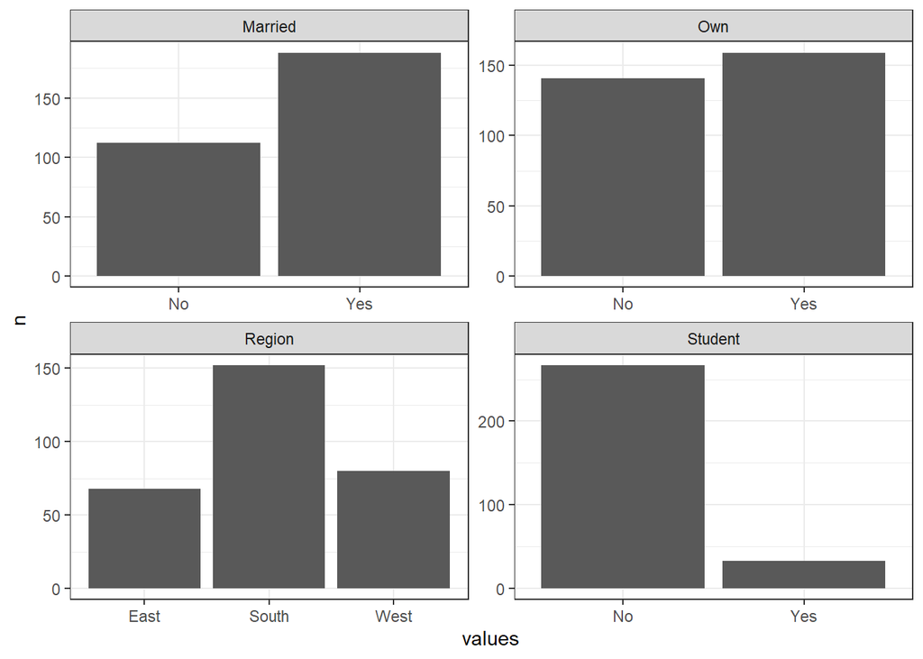

```r
library(dplyr); library(tidyr)
train %>%
  select(-Balance_hilo)%>%
  select_if(is.factor)%>%
  pivot_longer(cols = 1:4,names_to = 'categorical_predictor', values_to = 'values'  )%>%
  group_by(categorical_predictor, values)%>%
  count()%>%
  ungroup()%>%
  ggplot(aes(x = values, y = n))+
  geom_col()+
  facet_wrap(categorical_predictor~., scales = 'free')+
  theme_bw()
```

# Tree 1

We will use the library `rpart` to estimate trees, but note there are a number of other libraries that can be used. Since we are estimating a classification tree, we will set the method to `class`.

## Estimate

We will begin by predicting Credit Card `Balance_hilo` with just one predictor, `Age`.

```r
library(rpart); library(rpart.plot)
tree1 = rpart(Balance_hilo~Age,data = train, method = 'class')
```

## Inference

Here are model results.

```r
summary(tree1)
```

```
## Call:
## rpart(formula = Balance_hilo ~ Age, data = train, method = "class")
##   n= 300
##
##           CP nsplit rel error    xerror       xstd
## 1 0.04333333      0 1.0000000 1.1866667 0.05672024
## 2 0.02666667      2 0.9133333 1.0800000 0.05754998
## 3 0.01333333      6 0.7933333 0.9933333 0.05773374
## 4 0.01000000      8 0.7666667 0.9866667 0.05772989
##
## Variable importance
## Age
## 100
##
## Node number 1: 300 observations,    complexity param=0.04333333
##   predicted class=low   expected loss=0.5  P(node) =1
##     class counts:   150   150
##    probabilities: 0.500 0.500
##   left son=2 (282 obs) right son=3 (18 obs)
##   Primary splits:
##       Age < 29.5 to the right, improve=1.06383, (0 missing)
##
## Node number 2: 282 observations,    complexity param=0.04333333
##   predicted class=low   expected loss=0.4893617  P(node) =0.94
##     class counts:   144   138
##    probabilities: 0.511 0.489
##   left son=4 (253 obs) right son=5 (29 obs)
##   Primary splits:
##       Age < 79.5 to the left,  improve=1.11499, (0 missing)
##
## Node number 3: 18 observations
##   predicted class=high  expected loss=0.3333333  P(node) =0.06
##     class counts:     6    12
##    probabilities: 0.333 0.667
##
## Node number 4: 253 observations,    complexity param=0.02666667
##   predicted class=low   expected loss=0.4743083  P(node) =0.8433333
##     class counts:   133   120
##    probabilities: 0.526 0.474
##   left son=8 (49 obs) right son=9 (204 obs)
```

[output cut: 67 more lines]

```
##
## Node number 151: 68 observations
##   predicted class=high  expected loss=0.4117647  P(node) =0.2266667
##     class counts:    28    40
##    probabilities: 0.412 0.588
##
## Node number 300: 14 observations
##   predicted class=low   expected loss=0.3571429  P(node) =0.04666667
##     class counts:     9     5
##    probabilities: 0.643 0.357
##
## Node number 301: 14 observations
##   predicted class=high  expected loss=0.4285714  P(node) =0.04666667
##     class counts:     6     8
##    probabilities: 0.429 0.571
```

Model summary is easier to interpret as a Decision Tree.

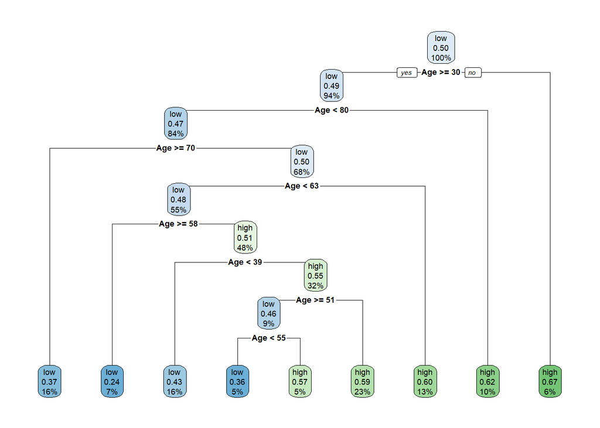

```r
rpart.plot(tree1)
```

Since age is being used as a split in the tree, Age is predictive of Balance_hilo. Furthermore, visual of the tree can be interpreted as a series of if-else conditionals with the predicted outcome in the leaves. For instance, for a 35 year old, one can navigate through the tree to arrive at a predicted probability of 0.43 for a “high” balance. Using a default 0.5 threshold, the predicted class is “low”.

To test your own understanding, see if you can find out the predictive probability and class for a 50 year old married man.

## Predict

The simplicity of the Tree makes it easy to predict class. However, this manual approach may not scale well for a large number of predictions. Also, for large complex trees, navigating the tree can be tedious. Like for logistic regression, one can use the `predict` function to get a predicted probability (use type = ‘prob’) or predicted class (use type = ‘class’). Let use see if we can replicate the results from the visual of the tree.

Predicted Probability for each class

```r
predict(tree1, newdata = data.frame(Age = 35), type='prob')
```

```
##         low      high
## 1 0.5744681 0.4255319
```

Predicted class

```r
predict(tree1, newdata = data.frame(Age = 35), type='class')
```

```
##   1
## low
## Levels: low high
```

You will note that the predicted class can be derived from the predictive probability for target class by using the default threshold of 0.5.

```r
predict(tree1, newdata = data.frame(Age = 35), type='prob')[,'high'] > 0.5
```

```
## [1] FALSE
```

Next, let us examine predictions for the first ten observations. Predictions include predicted probabilities (for each class) and predicted class.

```r
data.frame(predict(tree1, type='prob')[1:10,],
           predicted_class = predict(tree1, type = 'class')[1:10])
```

|  | low | high | predicted_class |
| --- | --- | --- | --- |
| 1 | 0.5744681 | 0.4255319 | low |
| 2 | 0.3793103 | 0.6206897 | high |
| 3 | 0.6326531 | 0.3673469 | low |
| 4 | 0.5744681 | 0.4255319 | low |
| 5 | 0.4000000 | 0.6000000 | high |
| 6 | 0.6326531 | 0.3673469 | low |
| 7 | 0.5744681 | 0.4255319 | low |
| 8 | 0.3793103 | 0.6206897 | high |
| 9 | 0.4000000 | 0.6000000 | high |
| 10 | 0.4117647 | 0.5882353 | high |

Unlike logistic regression, classification trees generate a limited number of unique predictions, each represented by the leaf of the visual of the tree. You can verify this by mapping the unique predictions below to the leaves in the above tree plot.

```r
unique(predict(tree1, type = 'prob'))
```

```
##          low      high
## 1  0.5744681 0.4255319
## 2  0.3793103 0.6206897
## 3  0.6326531 0.3673469
## 5  0.4000000 0.6000000
## 10 0.4117647 0.5882353
## 13 0.4285714 0.5714286
## 19 0.3333333 0.6666667
## 23 0.7619048 0.2380952
## 41 0.6428571 0.3571429
```

# Tree 2

Next, we will use all predictors to predict whether a person has “high” or “low” Balance.

## Estimate

```r
library(rpart); library(rpart.plot)
tree2 = rpart(Balance_hilo~.,data = train, method = 'class')
```

## Inference

Here is the classification tree `summary`.

```r
summary(tree2)
```

```
## Call:
## rpart(formula = Balance_hilo ~ ., data = train, method = "class")
##   n= 300
##
##           CP nsplit  rel error    xerror       xstd
## 1 0.74666667      0 1.00000000 1.1066667 0.05740564
## 2 0.06666667      1 0.25333333 0.3133333 0.04197177
## 3 0.01666667      3 0.12000000 0.2333333 0.03706851
## 4 0.01000000      5 0.08666667 0.1866667 0.03359012
##
## Variable importance
##    Rating     Limit    Income       Age     Cards Education
##        39        38        20         2         1         1
##
## Node number 1: 300 observations,    complexity param=0.7466667
##   predicted class=low   expected loss=0.5  P(node) =1
##     class counts:   150   150
##    probabilities: 0.500 0.500
##   left son=2 (114 obs) right son=3 (186 obs)
##   Primary splits:
##       Rating  < 288.5   to the left,  improve=88.737970, (0 missing)
##       Limit   < 4295.5  to the left,  improve=88.643370, (0 missing)
##       Income  < 62.3705 to the left,  improve=15.540020, (0 missing)
##       Student splits as  LR,          improve= 3.830439, (0 missing)
##       Cards   < 5.5     to the left,  improve= 1.348651, (0 missing)
##   Surrogate splits:
##       Limit  < 3772    to the left,  agree=0.983, adj=0.956, (0 split)
##       Income < 31.589  to the left,  agree=0.733, adj=0.298, (0 split)
##       Age    < 24.5    to the left,  agree=0.623, adj=0.009, (0 split)
##
## Node number 2: 114 observations
##   predicted class=low   expected loss=0.00877193  P(node) =0.38
##     class counts:   113     1
##    probabilities: 0.991 0.009
##
## Node number 3: 186 observations,    complexity param=0.06666667
##   predicted class=high  expected loss=0.1989247  P(node) =0.62
##     class counts:    37   149
##    probabilities: 0.199 0.801
##   left son=6 (82 obs) right son=7 (104 obs)
```

[output cut: 74 more lines]

```
##
## Node number 27: 27 observations
##   predicted class=high  expected loss=0  P(node) =0.09
##     class counts:     0    27
##    probabilities: 0.000 1.000
##
## Node number 52: 13 observations
##   predicted class=low   expected loss=0.3076923  P(node) =0.04333333
##     class counts:     9     4
##    probabilities: 0.692 0.308
##
## Node number 53: 20 observations
##   predicted class=high  expected loss=0.15  P(node) =0.06666667
##     class counts:     3    17
##    probabilities: 0.150 0.850
```

The tree `summary` can be tedious to interpret. The tree plot on the other hand is extremely easy to understand and explain to others.

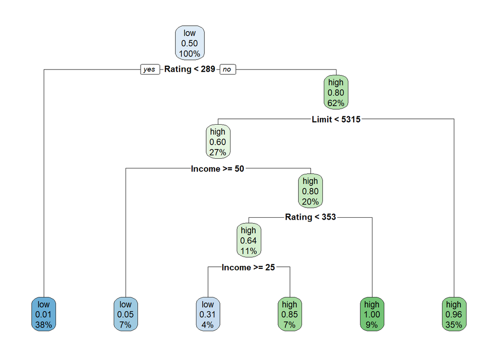

```r
rpart.plot(tree2)
```

Classification trees automatically conduct feature selection. Of all the predictors in the dataset, only the predictors included in the Classification Tree plot above have an influence on Balance_hilo.

The relative importance of the predictors can be determined by examining reduction in SSE attributed to each split. Intuitively, predictors that appear higher in the tree, or that appear multiple times in the tree will be more important than predictors that appear lower in the tree or not at all. Visual inspection of the above Tree indicates “Rating” is the most important, second is “Limit” and so on. Alternatively, one can extract relative importance from the Tree object. However, be aware that the Tree object, `tree2` also lists variable importance for predictors not included in the final tree!

```r
tree2$variable.importance
```

```
##     Rating      Limit     Income        Age      Cards  Education
## 104.669802 101.594884  54.448122   6.064070   2.183678   1.445626
```

## Predict

Next, we will use “tree2” to construct predictions for the train sample. We will extract predictions for the target class from the second column of the prediction matrix. For a classification tree, default type for `predict` is ‘prob’.

```r
pred2 = predict(tree2, type='prob')[,2]
```

The predicted probabilities can be used to derive the predicted class. Here, we will use a threshold of 0.5 and assign class labels to the predictions.

```r
pred2_class = factor(ifelse(pred2>0.5,'high','low'),
                     levels = c('low','high'))
```

Let us evaluate the quality of predictions on the train sample by comparing them to the true values. To get a flavor of the comparison, we will examine predicted probabilities, predicted class using a threshold of 0.5 and the true values for Balance_hilo for the first five observations.

```r
data.frame(Predicted_Prob = pred2,
           Predicted_Class = pred2_class,
           Balance_hilo = train$Balance)[1:5,]
```

|  | Predicted_Prob | Predicted_Class | Balance_hilo |
| --- | --- | --- | --- |
| 1 | 0.00877193 | low | low |
| 2 | 0.96153846 | high | high |
| 3 | 0.96153846 | high | high |
| 4 | 0.96153846 | high | high |
| 5 | 0.04545455 | low | low |

Next, let us examine the performance of predictions by examining proportion of classes predicted correctly, or accuracy of predictions. Alternatively, one can look at proportion of classes predicted incorrectly, known as as misclassification rate. While accuracy summarizes proportion of correct predictions, it doesn’t draw a distinction between which class is predicted correctly. In cases where the cost of misprediction across classes differ, one should also look at Specificity and Sensitivity.

Accuracy, Specificity and Sensitivity can be derived from the classification table or matrix. Classification Table

```r
ct = table(train$Balance_hilo,pred2_class); ct
```

```
##       pred2_class
##        low high
##   low  143    7
##   high   6  144
```

Accuracy

```r
accuracy2 = sum(ct[1,1],ct[2,2])/nrow(train); accuracy2
```

```
## [1] 0.9566667
```

Specificity

```r
specificity2 = ct[1,1]/sum(ct[1,1],ct[1,2]); specificity2
```

```
## [1] 0.9533333
```

Sensitivity

```r
sensitivity2 = ct[2,2]/sum(ct[2,1],ct[2,2]); sensitivity2
```

```
## [1] 0.96
```

The Classification matrix is also known as a Confusion matrix. This is also the name of a `library(caret)` function that compiles a set of performance metrics.

```r
library(caret)
confusionMatrix(data = pred2_class,
                reference = train$Balance_hilo,
                positive = 'high')
```

```
## Confusion Matrix and Statistics
##
##           Reference
## Prediction low high
##       low  143    6
##       high   7  144
##
##                Accuracy : 0.9567
##                  95% CI : (0.927, 0.9767)
##     No Information Rate : 0.5
##     P-Value [Acc > NIR] : <2e-16
##
##                   Kappa : 0.9133
##
##  Mcnemar's Test P-Value : 1
##
##             Sensitivity : 0.9600
##             Specificity : 0.9533
##          Pos Pred Value : 0.9536
##          Neg Pred Value : 0.9597
##              Prevalence : 0.5000
##          Detection Rate : 0.4800
##    Detection Prevalence : 0.5033
##       Balanced Accuracy : 0.9567
##
##        'Positive' Class : high
##
```

# Tree Control

`rpart` contains a number of control parameters to affect the growth and complexity of the tree.

1. minsplit: the minimum number of observations that must exist in a node in order for a split to be attempted.
2. maxdepth: the maximum depth of any node of the final tree
3. cp: complexity parameter
4. minbucket: the minimum number of observations in any terminal node

For more information on controls, run `?rpart.control` or see [documentation for rpart.control](https://www.rdocumentation.org/packages/rpart/versions/4.1-15/topics/rpart.control).

Among these, minsplit, minbucket, and maxdepth directly impact the size of the tree. The complexity parameter, cp is used to add a penalty for a large tree. Here size of the tree is measured by number of leaves. The penalty is the product of cp and number of leaves. So, large values of cp will result in smaller trees while small values of cp will result in larger more complex trees.

We will examine the effect of changing each one of these parameters on Tree size. Our baseline for comparison is the default values used in `tree2` above.

## minsplit

Default value for minsplit is 20. Increasing minsplit leads to a smaller tree.

```r
tree3 = rpart(Balance_hilo~.,data = train, method = 'class', control = rpart.control(minsplit = 100))
rpart.plot(tree3)
```

[output not shown]

## maxdepth

Smaller the value of maxdepth, smaller the tree. A depth of 2 implies, two levels of nodes after the root node.

```r
tree4 = rpart(Balance_hilo~.,data = train, method = 'class', control = rpart.control(maxdepth = 2))
rpart.plot(tree4)
```

[output not shown]

## cp

Larger the complexity parameter, cp, the greater the penalty for complexity which will result in smaller trees. The default value of cp is 0.01.

```r
tree5 = rpart(Balance_hilo~.,data = train, method = 'class', control = rpart.control(cp = 0.1))
rpart.plot(tree5)
```

[output not shown]

## minbucket

Default value for minbucket is 7 (=round(20/3)). Increasing minbucket leads to a smaller tree.

```r
tree6 = rpart(Balance_hilo~.,data = train, method = 'class', control = rpart.control(minbucket = 50))
rpart.plot(tree6)
```

[output not shown]

```r
pred6 = predict(tree6, type='prob')[,2]
pred6_class = factor(ifelse(pred6>0.5,'high','low'),
                     levels = c('low','high'))
ct = table(train$Balance_hilo,pred6_class)
accuracy6 = sum(ct[1,1],ct[2,2])/nrow(train); accuracy6
```

```
## [1] 0.8733333
```

Let us experiment with a smaller minbucket of 2 to see its impact on accuracy. As expected, this results in a large bushy Tree.

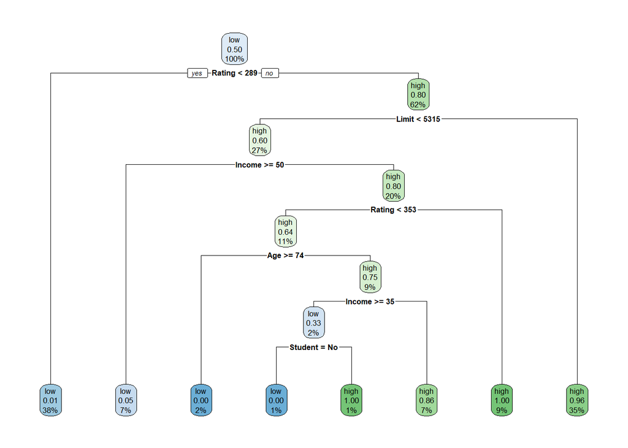

```r
tree7 = rpart(Balance_hilo~., data = train, method = 'class', control = rpart.control(minbucket = 2))
rpart.plot(tree7)
```

```r
pred7 = predict(tree7, type='prob')[,2]
pred7_class = factor(ifelse(pred7>0.5,'high','low'),
                     levels = c('low','high'))
ct = table(train$Balance_hilo,pred7_class)
accuracy7 = sum(ct[1,1],ct[2,2])/nrow(train); accuracy7
```

```
## [1] 0.97
```

To sum up, the results indicate that lower values of minbucket lead to better accuracy in the train sample.

```r
data.frame(Tree = c('tree2', 'tree6', 'tree7'),
           minbucket = c(7, 50,  2),
           accuracy_train = c(accuracy2, accuracy6, accuracy7))%>%
  arrange(desc(minbucket))
```

| Tree | minbucket | accuracy_train |
| --- | --- | --- |
| tree6 | 50 | 0.8733333 |
| tree2 | 7 | 0.9566667 |
| tree7 | 2 | 0.9700000 |

The ultimate test of a model is how it performs on a different sample. Furthermore, we know that accuracy is sensitive to the cutoff threshold, so we will also examine Area under the ROC curve, or AUC as it is independent of the cutoff. We will begin with tree2 and then repeat the analysis for tree6 and tree7.

```r
pred2_test = predict(tree2, type='prob', newdata = test)[,2]
pred2_test_class = factor(ifelse(pred2_test>0.5,'high','low'),
                     levels = c('low','high'))
ct = table(test$Balance_hilo,pred2_test_class)
accuracy2_test = sum(ct[1,1],ct[2,2])/nrow(test); accuracy2_test
```

```
## [1] 0.95
```

```r
library(ROCR)
ROCRPred = prediction(predictions = pred2_test, labels = test$Balance_hilo)
auc2 = as.numeric(performance(prediction.obj = ROCRPred,measure = 'auc')@y.values); auc2
```

```
## [1] 0.969
```

```r
pred6_test = predict(tree6, type='prob', newdata = test)[,2]
pred6_test_class = factor(ifelse(pred6_test>0.5,'high','low'),
                     levels = c('low','high'))
ct = table(test$Balance_hilo,pred6_test_class)
accuracy6_test = sum(ct[1,1],ct[2,2])/nrow(test); accuracy6_test
```

```
## [1] 0.8
```

```r
library(ROCR)
ROCRPred = prediction(predictions = pred6_test, labels = test$Balance_hilo)
auc6 = as.numeric(performance(prediction.obj = ROCRPred,measure = 'auc')@y.values); auc6
```

```
## [1] 0.8
```

```r
pred7_test = predict(tree7, type='prob', newdata = test)[,2]
pred7_test_class = factor(ifelse(pred7_test>0.5,'high','low'),
                     levels = c('low','high'))
ct = table(test$Balance_hilo,pred7_test_class)
accuracy7_test = sum(ct[1,1],ct[2,2])/nrow(test); accuracy7_test
```

```
## [1] 0.92
```

```r
library(ROCR)
ROCRPred = prediction(predictions = pred7_test, labels = test$Balance_hilo)
auc7 = as.numeric(performance(prediction.obj = ROCRPred,measure = 'auc')@y.values); auc7
```

```
## [1] 0.9552
```

## Results

The results indicate, reducing minbucket leads to better performance on the train sample. For the test sample, performance in terms of both, accuracy and AUC, improves and then gets worse. Our best performing model on the test sample is tree2 with a minbucket of 7.

```r
data.frame(Tree = c('tree2', 'tree6', 'tree7'),
           minbucket = c(7, 50, 2),
           accuracy_train = c(accuracy2, accuracy6, accuracy7),
           accuracy_test = c(accuracy2_test, accuracy6_test, accuracy7_test),
           auc_test = c(auc2, auc6, auc7))%>%
  arrange(desc(minbucket))
```

| Tree | minbucket | accuracy_train | accuracy_test | auc_test |
| --- | --- | --- | --- | --- |
| tree6 | 50 | 0.8733333 | 0.80 | 0.8000 |
| tree2 | 7 | 0.9566667 | 0.95 | 0.9690 |
| tree7 | 2 | 0.9700000 | 0.92 | 0.9552 |